# 膳食添加糖摄入与成人血脂异常的关联分析

2026-06-08

## 1 1. 研究背景

### 1.1 1.1 心血管疾病的流行病学负担

```
心血管疾病（CVD）是全球范围内导致死亡和残疾的主要原因之一。根据世界卫生组织（WHO）数据，2019 年全球约有 1790 万人死于心血管疾病，占总死亡人数的 32%。其中，缺血性心脏病和脑卒中是最主要的死亡原因。中国心血管疾病患病率持续上升，现患人数约 3.3 亿，心血管疾病已成为我国居民的首位死因，占城乡居民总死亡原因的 40% 以上。
```

### 1.2 1.2 血脂异常是心血管疾病的重要危险因素

```
血脂异常是心血管疾病的关键可调控危险因素。大量流行病学研究和随机对照试验证实，血清总胆固醇（TC）、甘油三酯（TG）、低密度脂蛋白胆固醇（LDL-C）水平升高，以及高密度脂蛋白胆固醇（HDL-C）水平降低，均与动脉粥样硬化性心血管疾病（ASCVD）风险增加密切相关。《中国心血管病一级预防指南》指出，控制血脂异常可显著降低心血管事件的发生率和死亡率。
```

## 2 2. 研究问题

基于上述研究背景，本研究利用2017-2018年美国国家健康与营养调查（NHANES）数据，旨在： 描述不同添加糖摄入水平下成年人的血脂异常患病情况；分析膳食添加糖摄入与血脂异常的关联；探讨添加糖摄入与血脂的剂量-反应关系；为制定针对性的膳食指南和心血管疾病防控策略提供科学依据。

## 3 3. 数据来源与研究对象

### 3.1 3.1 数据来源

本研究使用美国国家健康与营养调查（National Health and Nutrition Examination Survey, NHANES）2017-2018年数据。NHANES是一项连续、分层的全国代表性横断面调查，采用复杂多阶段概率抽样设计，每两年为一个周期。所有数据均已公开，可在官方网站下载。

### 3.2 3.2 研究对象

本研究纳入标准如下： 年龄 ≥18 岁的成年人 完成膳食调查（DR1TOT_J.XPT） 完成血脂检测（TCHOL_J.XPT、TRIGLY_J.XPT、HDL_J.XPT） 排除标准如下： 关键变量（添加糖摄入、血脂指标）缺失者

## 4 4. 变量说明

暴露变量：添加糖摄入量（三分位数分组：低 / 中 / 高） 结局变量：血脂异常（TC≥240mg/dL, TG≥200mg/dL, HDL<40/50mg/dL, LDL≥160mg/dL） 协变量：年龄、性别、种族、教育、收入、BMI、总能量摄入

## 5 5. 数据清洗

```r
# 加载包
library(haven)
library(dplyr)
library(tableone)


# 5.1 读取并合并原始数据
demo   <- read_xpt("doc/DEMO_J.XPT")
bmx    <- read_xpt("doc/BMX_J.XPT")
dr1tot <- read_xpt("doc/DR1TOT_J.XPT")
tc_dat    <- read_xpt("doc/TCHOL_J.XPT")
tgldl_dat <- read_xpt("doc/TRIGLY_J.XPT")
hdl_dat   <- read_xpt("doc/HDL_J.XPT")

# 合并四项血脂
lipid <- tc_dat %>% select(SEQN, LBXTC) %>%
  inner_join(tgldl_dat %>% select(SEQN, LBXTR, LBDLDL), by = "SEQN") %>%
  inner_join(hdl_dat %>% select(SEQN, LBDHDD), by = "SEQN") %>%
  rename(LBXHD = LBDHDD)

# 全天添加糖三分组：低/中/高
sugar_data <- dr1tot[,c("SEQN","DR1TSUGR","DR1TKCAL")]

cut_q <- quantile(sugar_data$DR1TSUGR, probs = c(0,1/3,2/3,1), na.rm=TRUE)

sugar_data$exposure_3 <- cut(sugar_data$DR1TSUGR,
                             breaks = cut_q,
                             labels = c("低添加糖","中添加糖","高添加糖"),
                             include.lowest = TRUE)

sugar_data$exposure_3 <- factor(sugar_data$exposure_3,
                                levels=c("低添加糖","中添加糖","高添加糖"))

# 数据合并
df_all <- inner_join(demo,bmx,by="SEQN") %>% inner_join(sugar_data,by="SEQN")
df <- inner_join(df_all,lipid,by="SEQN")


# 5.2 筛选变量和样本

# 关键变量
keep_var <- c("SEQN","exposure_3","RIDAGEYR","RIAGENDR","RIDRETH1","DMDEDUC2","INDFMPIR",
              "BMXBMI","DR1TKCAL","DR1TSUGR","LBXTC","LBXTR","LBXHD","LBDLDL")

# 筛选成年人
df_adult <- subset(df, RIDAGEYR >= 18)

cat("1. 成年原始样本量：", nrow(df_adult), "\n")
```

```
## 1. 成年原始样本量： 2652
```

```r
# 筛选变量
df_sel <- df_adult[, keep_var]
cat("2. 筛选变量后样本量：", nrow(df_sel), "\n")
```

```
## 2. 筛选变量后样本量： 2652
```

```r
# 5.3 缺失值处理

# 剔除核心变量缺失（暴露+血脂）
key_vars <- c("exposure_3", "LBXTC", "LBXTR", "LBXHD", "LBDLDL")
df_clean <- df_sel[complete.cases(df_sel[, key_vars]), ]
cat("\n3. 剔除核心变量缺失后样本量：", nrow(df_clean), "\n")
```

```
##
## 3. 剔除核心变量缺失后样本量： 2247
```

```r
# 连续型协变量 BMXBMI、INDFMPIR：中位数插补
bmi_med <- median(df_clean$BMXBMI, na.rm = TRUE)
df_clean$BMXBMI[is.na(df_clean$BMXBMI)] <- bmi_med

indf_med <- median(df_clean$INDFMPIR, na.rm = TRUE)
df_clean$INDFMPIR[is.na(df_clean$INDFMPIR)] <- indf_med

# 分类变量 DMDEDUC2：众数插补
get_mode <- function(x){
  tbl <- table(x)
  mode_str <- names(tbl)[which.max(tbl)]
  if(is.numeric(x)){
    return(as.numeric(mode_str))
  }else{
    return(mode_str)
  }
}
df_clean$DMDEDUC2[is.na(df_clean$DMDEDUC2)] <- get_mode(df_clean$DMDEDUC2)


# 5.4 异常值处理（缩尾法）
# 计算总能量摄入 1% 和 99% 分位数
q01 <- quantile(df_clean$DR1TKCAL, 0.01, na.rm = TRUE)
q99 <- quantile(df_clean$DR1TKCAL, 0.99, na.rm = TRUE)

# 缩尾处理
df_clean$DR1TKCAL_winsor <- df_clean$DR1TKCAL
df_clean$DR1TKCAL_winsor[df_clean$DR1TKCAL < q01] <- q01
df_clean$DR1TKCAL_winsor[df_clean$DR1TKCAL > q99] <- q99

cat("\n4. 插补+缩尾后样本量：", nrow(df_clean), "\n")
```

```
##
## 4. 插补+缩尾后样本量： 2247
```

```r
# 5.5 生成最终分析数据集 df_final
df_final <- df_clean %>%
  mutate(
    high_tc  = ifelse(LBXTC >= 240, 1, 0),
    high_tg  = ifelse(LBXTR >= 200, 1, 0),
    low_hdl  = ifelse((RIAGENDR == 1 & LBXHD < 40) | (RIAGENDR == 2 & LBXHD < 50), 1, 0),
    high_ldl = ifelse(LBDLDL >= 160, 1, 0)
  )

cat("5. 最终分析样本量：", nrow(df_final), "\n")
```

```
## 5. 最终分析样本量： 2247
```

```r
# 5.6 保存清洗后的数据
saveRDS(df_final, "df_cleaned.rds")
```

## 6 6. 描述性统计

```r
library(tableone)
library(dplyr)

# 前置核查：缺失值统计
# 定义连续、分类变量集合
con_vars <- c("RIDAGEYR", "BMXBMI", "DR1TSUGR", "DR1TKCAL", "DR1TKCAL_winsor",
              "LBXTC", "LBXTR", "LBXHD", "LBDLDL", "INDFMPIR")
cat_vars <- c("RIAGENDR", "RIDRETH1", "DMDEDUC2","exposure_3", "high_tc",
              "high_tg", "low_hdl", "high_ldl")
# 统计各变量缺失样本数量
colSums(is.na(df_final[, c(con_vars, cat_vars)]))
```

```
##        RIDAGEYR          BMXBMI        DR1TSUGR        DR1TKCAL DR1TKCAL_winsor
##               0               0               0               0               0
##           LBXTC           LBXTR           LBXHD          LBDLDL        INDFMPIR
##               0               0               0               0               0
##        RIAGENDR        RIDRETH1        DMDEDUC2      exposure_3         high_tc
##               0               0               0               0               0
##         high_tg         low_hdl        high_ldl
##               0               0               0
```

```r
# 定义偏态分布连续变量（基线表采用中位数[四分位数]展示）
nonnormal_vars <- c("BMXBMI", "DR1TSUGR", "DR1TKCAL", "DR1TKCAL_winsor",
                    "LBXTC", "LBXTR", "LBXHD", "LBDLDL", "INDFMPIR")
# 将全部分类变量转换为因子格式
df_final[cat_vars] <- lapply(df_final[cat_vars], factor)

# 单变量分布核查
## 分类变量频数统计
for(v in cat_vars){
  print(table(df_final[[v]]))
}
```

```
##
##    1    2
## 1082 1165
##
##   1   2   3   4   5
## 323 207 792 521 404
##
##   1   2   3   4   5   9
## 160 259 521 801 504   2
##
## 低添加糖 中添加糖 高添加糖
##      784      690      773
##
##    0    1
## 2036  211
##
##    0    1
## 2067  180
##
##    0    1
## 1616  631
##
##    0    1
## 2052  195
```

```r
## 连续变量极值、四分位数汇总统计
lapply(df_final[, con_vars], summary)
```

```
## $RIDAGEYR
##    Min. 1st Qu.  Median    Mean 3rd Qu.    Max.
##   18.00   34.00   52.00   49.83   64.00   80.00
##
## $BMXBMI
##    Min. 1st Qu.  Median    Mean 3rd Qu.    Max.
##    15.5    24.5    28.3    29.7    33.5    74.8
##
## $DR1TSUGR
##    Min. 1st Qu.  Median    Mean 3rd Qu.    Max.
##    0.00   55.16   89.50  106.11  137.98  931.16
##
## $DR1TKCAL
##    Min. 1st Qu.  Median    Mean 3rd Qu.    Max.
##       3    1406    1956    2102    2642   12501
##
## $DR1TKCAL_winsor
##    Min. 1st Qu.  Median    Mean 3rd Qu.    Max.
##   478.3  1406.0  1956.0  2092.3  2641.5  5330.7
##
## $LBXTC
##    Min. 1st Qu.  Median    Mean 3rd Qu.    Max.
##    76.0   156.0   180.0   184.8   209.0   446.0
##
## $LBXTR
##    Min. 1st Qu.  Median    Mean 3rd Qu.    Max.
##    10.0    61.0    92.0   105.9   133.0   399.0
##
## $LBXHD
##    Min. 1st Qu.  Median    Mean 3rd Qu.    Max.
##   11.00   42.00   51.00   53.74   62.00  178.00
##
## $LBDLDL
##    Min. 1st Qu.  Median    Mean 3rd Qu.    Max.
##    18.0    85.0   107.0   109.9   131.0   357.0
##
## $INDFMPIR
##    Min. 1st Qu.  Median    Mean 3rd Qu.    Max.
##   0.000   1.320   2.070   2.475   3.690   5.000
```

```r
# 生成全样本总体基线特征表
tab_total <- CreateTableOne(
  vars = c(con_vars, cat_vars),
  data = df_final,
  factorVars = cat_vars
)
# 输出基线表，偏态变量使用中位数(IQR)，P值保留3位小数
print(tab_total,
      showAllLevels = TRUE,
      nonnormal = nonnormal_vars,
      pDigits = 3
)
```

```
##
##                                  level    Overall
##   n                                          2247
##   RIDAGEYR (mean (SD))                      49.83 (18.31)
##   BMXBMI (median [IQR])                     28.30 [24.50, 33.50]
##   DR1TSUGR (median [IQR])                   89.50 [55.16, 137.98]
##   DR1TKCAL (median [IQR])                 1956.00 [1406.00, 2641.50]
##   DR1TKCAL_winsor (median [IQR])          1956.00 [1406.00, 2641.50]
##   LBXTC (median [IQR])                     180.00 [156.00, 209.00]
##   LBXTR (median [IQR])                      92.00 [61.00, 133.00]
##   LBXHD (median [IQR])                      51.00 [42.00, 62.00]
##   LBDLDL (median [IQR])                    107.00 [85.00, 131.00]
##   INDFMPIR (median [IQR])                    2.07 [1.32, 3.69]
##   RIAGENDR (%)                   1           1082 (48.2)
##                                  2           1165 (51.8)
##   RIDRETH1 (%)                   1            323 (14.4)
##                                  2            207 ( 9.2)
##                                  3            792 (35.2)
##                                  4            521 (23.2)
##                                  5            404 (18.0)
##   DMDEDUC2 (%)                   1            160 ( 7.1)
##                                  2            259 (11.5)
##                                  3            521 (23.2)
##                                  4            801 (35.6)
##                                  5            504 (22.4)
##                                  9              2 ( 0.1)
##   exposure_3 (%)                 低添加糖     784 (34.9)
##                                  中添加糖     690 (30.7)
##                                  高添加糖     773 (34.4)
##   high_tc (%)                    0           2036 (90.6)
##                                  1            211 ( 9.4)
##   high_tg (%)                    0           2067 (92.0)
##                                  1            180 ( 8.0)
##   low_hdl (%)                    0           1616 (71.9)
##                                  1            631 (28.1)
##   high_ldl (%)                   0           2052 (91.3)
##                                  1            195 ( 8.7)
```

```r
# 生成膳食添加糖三分组分层基线表与组间差异检验
tab_group <- CreateTableOne(
  vars = c(con_vars, cat_vars),
  strata = "exposure_3", # 分层变量：膳食添加糖三分组
  data = df_final,
  factorVars = cat_vars
)
print(tab_group,
      showAllLevels = TRUE,
      nonnormal = nonnormal_vars,
      pDigits = 3,
      test = TRUE)
```

```
##                                 Stratified by exposure_3
##                                  level    低添加糖
##   n                                           784
##   RIDAGEYR (mean (SD))                      50.96 (18.35)
##   BMXBMI (median [IQR])                     28.30 [24.60, 34.10]
##   DR1TSUGR (median [IQR])                   44.52 [31.09, 57.13]
##   DR1TKCAL (median [IQR])                 1394.00 [1030.75, 1857.75]
##   DR1TKCAL_winsor (median [IQR])          1394.00 [1030.75, 1857.75]
##   LBXTC (median [IQR])                     182.00 [159.00, 212.00]
##   LBXTR (median [IQR])                      91.50 [61.00, 130.00]
##   LBXHD (median [IQR])                      52.00 [43.00, 64.00]
##   LBDLDL (median [IQR])                    106.00 [87.00, 132.25]
##   INDFMPIR (median [IQR])                    2.07 [1.35, 3.98]
##   RIAGENDR (%)                   1            328 ( 41.8)
##                                  2            456 ( 58.2)
##   RIDRETH1 (%)                   1            104 ( 13.3)
##                                  2             74 (  9.4)
##                                  3            247 ( 31.5)
##                                  4            178 ( 22.7)
##                                  5            181 ( 23.1)
##   DMDEDUC2 (%)                   1             64 (  8.2)
##                                  2            101 ( 12.9)
##                                  3            174 ( 22.2)
##                                  4            260 ( 33.2)
##                                  5            184 ( 23.5)
##                                  9              1 (  0.1)
##   exposure_3 (%)                 低添加糖     784 (100.0)
##                                  中添加糖       0 (  0.0)
##                                  高添加糖       0 (  0.0)
##   high_tc (%)                    0            700 ( 89.3)
##                                  1             84 ( 10.7)
##   high_tg (%)                    0            728 ( 92.9)
##                                  1             56 (  7.1)
##   low_hdl (%)                    0            560 ( 71.4)
##                                  1            224 ( 28.6)
##   high_ldl (%)                   0            713 ( 90.9)
##                                  1             71 (  9.1)
##                                 Stratified by exposure_3
##                                  中添加糖
##   n                                  690
```

[output cut: 56 more lines]

```
##                                      185 ( 23.9)
##                                      302 ( 39.1)
##                                      154 ( 19.9)
##                                        0 (  0.0)
##   exposure_3 (%)                       0 (  0.0)            <0.001
##                                        0 (  0.0)
##                                      773 (100.0)
##   high_tc (%)                        710 ( 91.8)             0.221
##                                       63 (  8.2)
##   high_tg (%)                        701 ( 90.7)             0.247
##                                       72 (  9.3)
##   low_hdl (%)                        541 ( 70.0)             0.132
##                                      232 ( 30.0)
##   high_ldl (%)                       710 ( 91.8)             0.804
##                                       63 (  8.2)
```

```r
# 将基线统计表导出为CSV文件
## 导出全样本总体基线表
tab_total_export <- print(tab_total,
                          showAllLevels = TRUE,
                          nonnormal = nonnormal_vars,
                          pDigits = 3,
                          printToggle = FALSE)
write.csv(tab_total_export, file="总体描述统计表.csv", row.names = TRUE)

## 导出三分组分层基线表（附带组间差异P值）
tab_group_export <- print(tab_group,
                          showAllLevels = TRUE,
                          nonnormal = nonnormal_vars,
                          pDigits = 3,
                          test = TRUE,
                          printToggle = FALSE)
write.csv(tab_group_export, file="分组描述统计表.csv", row.names = TRUE)
```

## 7 7.数据可视化

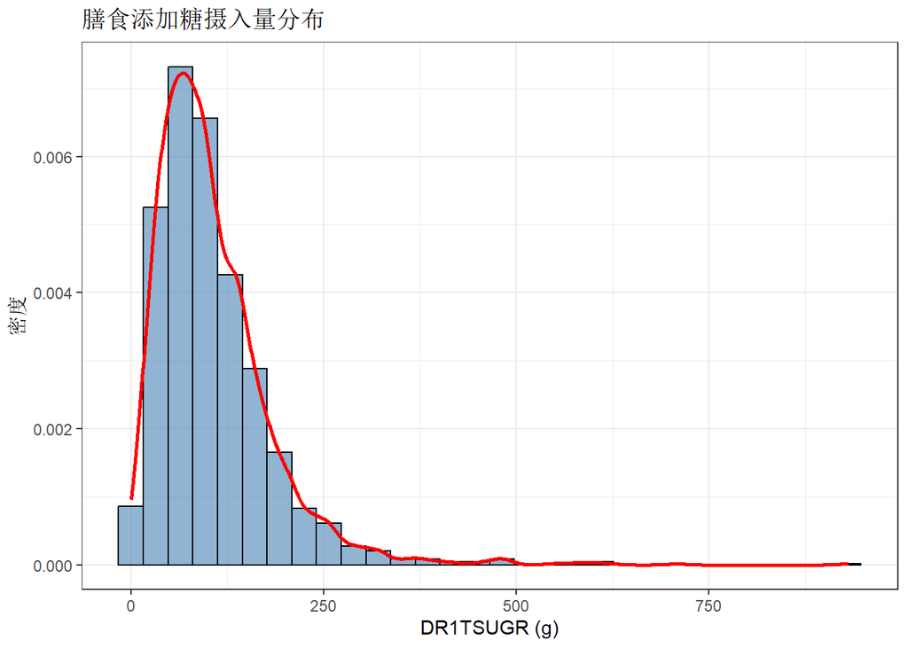

```r
# 7.1 绘图包加载与变量分布可视化
# 加载绘图、拼图工具包
library(ggplot2)
library(patchwork)

# 将分组暴露变量转换为因子
df_final$exposure_3 <- factor(df_final$exposure_3)

## 7.1.1 膳食添加糖单变量分布直方图+密度曲线
ggplot(data = df_final, aes(x = DR1TSUGR, y = ..density..)) +
  geom_histogram(bins = 30, fill = "steelblue", alpha = 0.6, color = "black") +
  geom_density(color = "red", size = 1)+
  labs(title = "膳食添加糖摄入量分布", x = "DR1TSUGR (g)", y = "密度") +
  theme_bw()
```

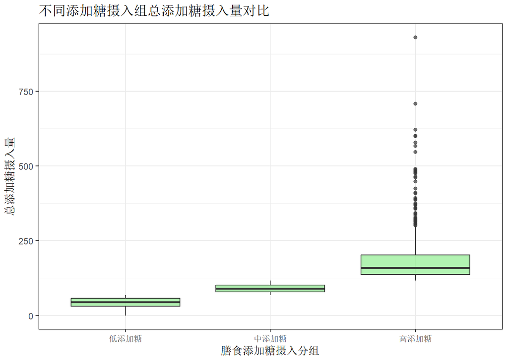

```r
## 7.1.2 四分类血脂指标分组箱线图拼接
# 总添加糖分组箱线图
ggplot(data = df_final, aes(x = exposure_3, y = DR1TSUGR)) +
  geom_boxplot(fill = "lightgreen", alpha = 0.7) +
  labs(
    x = "膳食添加糖摄入分组",
    y = "总添加糖摄入量",
    title = "不同添加糖摄入组总添加糖摄入量对比"
  ) +
  theme_bw()
```

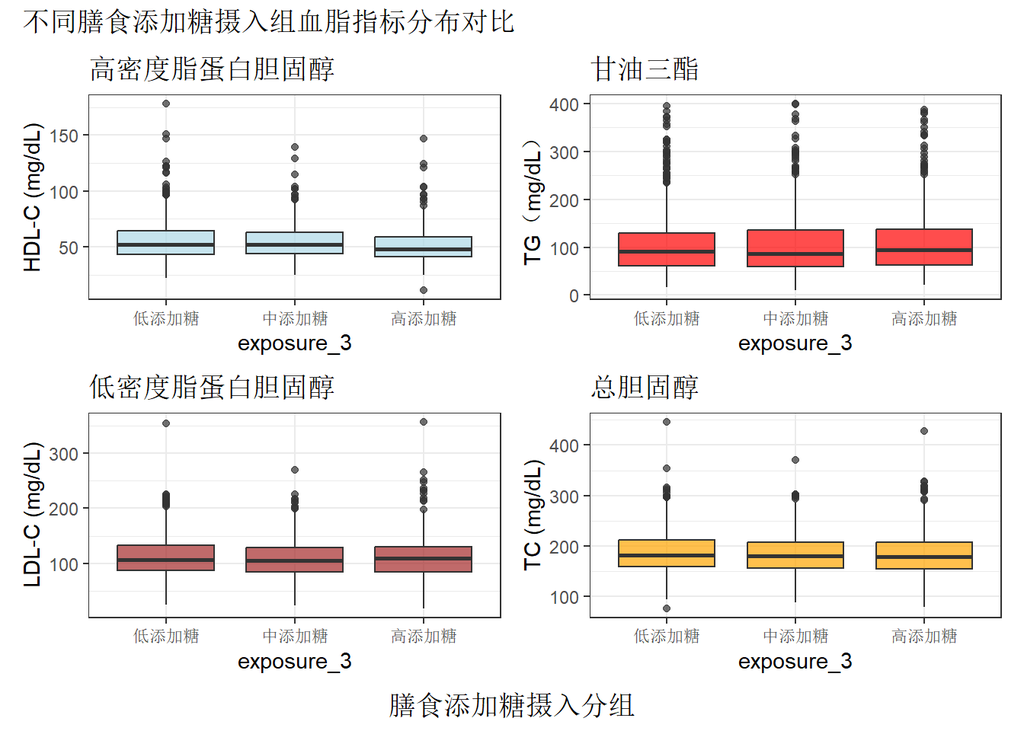

```r
# 各血脂指标箱线图
p_hdl <- ggplot(data = df_final, aes(x = exposure_3, y = LBXHD)) +
  geom_boxplot(fill = "lightblue", alpha = 0.7) +
  labs(y = "HDL-C (mg/dL)", title = "高密度脂蛋白胆固醇") +
  theme_bw()

p_tg <- ggplot(data = df_final, aes(x = exposure_3, y = LBXTR)) +
  geom_boxplot(fill = "red", alpha = 0.7) +
  labs(y = "TG（mg/dL）", title = "甘油三酯") +
  theme_bw()

p_ldl <- ggplot(data = df_final, aes(x = exposure_3, y = LBDLDL)) +
  geom_boxplot(fill = "brown", alpha = 0.7) +
  labs(y = "LDL-C (mg/dL)", title = "低密度脂蛋白胆固醇") +
  theme_bw()

p_tc <- ggplot(data = df_final, aes(x = exposure_3, y = LBXTC)) +
  geom_boxplot(fill = "orange", alpha = 0.7) +
  labs(y = "TC (mg/dL)", title = "总胆固醇") +
  theme_bw()

# 2行2列拼接四张血脂箱线图
all_lipid <- (p_hdl + p_tg) / (p_ldl + p_tc)
all_lipid + plot_annotation(
  title = "不同膳食添加糖摄入组血脂指标分布对比",
  caption = "膳食添加糖摄入分组"
) & theme(
  plot.caption = element_text(hjust = 0.5, size = 13)
)
```

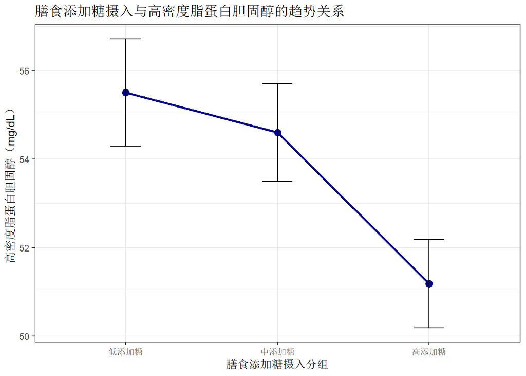

```r
# 7.2 分组均值与95%置信区间误差棒趋势图
library(dplyr)
df_group <- group_by(df_final, exposure_3)

## HDL-C分组均值趋势图
df_trend_hdl <- summarise(
  df_group,
  mean_hdl = mean(LBXHD, na.rm = TRUE),
  se_hdl = sd(LBXHD, na.rm = TRUE)/sqrt(n()),
  lower = mean_hdl - 1.96*se_hdl,
  upper = mean_hdl + 1.96*se_hdl
)
ggplot(data = df_trend_hdl, aes(x = exposure_3, y = mean_hdl, group = 1)) +
  geom_point(size = 3, color = "darkblue") +
  geom_line(color = "darkblue", linewidth = 1) +
  geom_errorbar(aes(ymin = lower, ymax = upper), width = 0.2) +
  labs(
    title = "膳食添加糖摄入与高密度脂蛋白胆固醇的趋势关系",
    x = "膳食添加糖摄入分组",
    y = "高密度脂蛋白胆固醇（mg/dL）"
  ) +
  theme_bw()
```

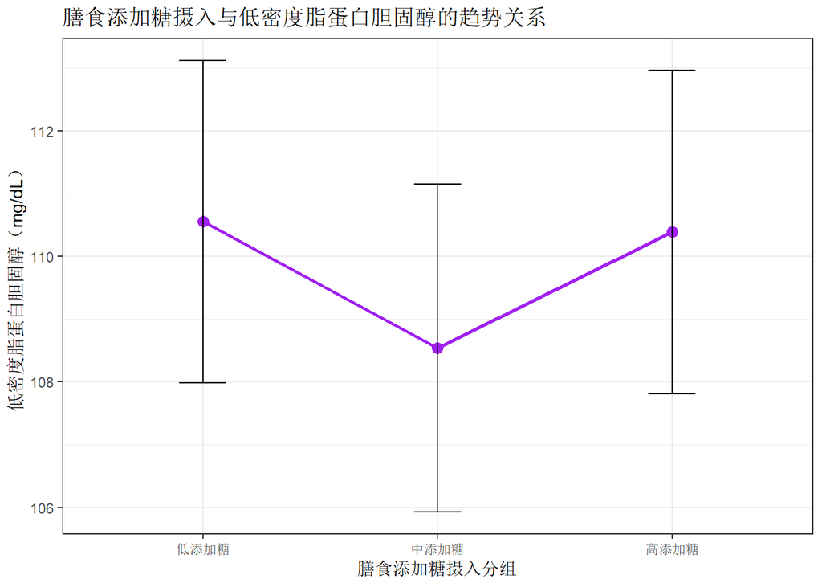

```r
## LDL-C分组均值趋势图
df_trend_ldl <- summarise(
  df_group,
  mean_ldl = mean(LBDLDL, na.rm = TRUE),
  se_ldl = sd(LBDLDL, na.rm = TRUE)/sqrt(n()),
  lower = mean_ldl - 1.96 * se_ldl,
  upper = mean_ldl + 1.96 * se_ldl
)
ggplot(data = df_trend_ldl, aes(x = exposure_3, y = mean_ldl, group = 1)) +
  geom_point(size = 3, color = "purple") +
  geom_line(color = "purple", linewidth = 1) +
  geom_errorbar(aes(ymin = lower, ymax = upper), width = 0.2) +
  labs(
    title = "膳食添加糖摄入与低密度脂蛋白胆固醇的趋势关系",
    x = "膳食添加糖摄入分组",
    y = "低密度脂蛋白胆固醇（mg/dL）"
  ) +
  theme_bw()
```

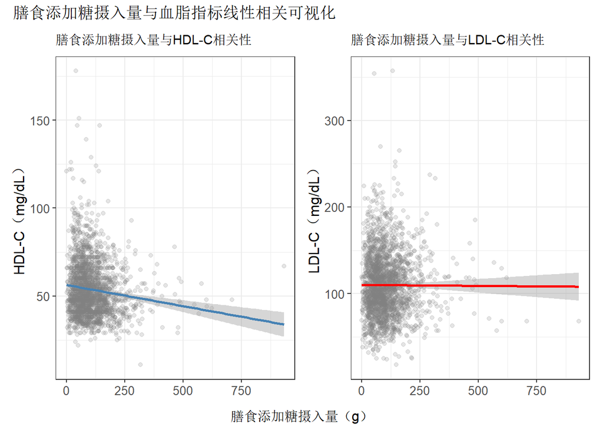

```r
# 7.3 膳食添加糖与血脂线性相关散点拟合图
## 添加糖与HDL-C散点+线性拟合曲线
p_scatter_hdl <- ggplot(data = df_final, aes(x = DR1TSUGR, y = LBXHD)) +
  geom_point(alpha = 0.2, color = "gray50") +
  geom_smooth(method = "lm", color = "steelblue", linewidth = 1, se = TRUE) +
  labs(
    title = "膳食添加糖摄入量与HDL-C相关性",
    x = "膳食添加糖摄入量（g）",
    y = "HDL-C（mg/dL）"
  ) +
  theme_bw() + theme(
    plot.title = element_text(size = 11, margin = margin(b = 8)),
    axis.title = element_text(size = 12),
    axis.text = element_text(size = 10),
    axis.title.x = element_blank()
  )

## 添加糖与LDL-C散点+线性拟合曲线
p_scatter_ldl <- ggplot(data = df_final, aes(x = DR1TSUGR, y = LBDLDL)) +
  geom_point(alpha = 0.2, color = "gray50") +
  geom_smooth(method = "lm", color = "red", linewidth = 1, se = TRUE) +
  labs(
    title = "膳食添加糖摄入量与LDL-C相关性",
    x = "膳食添加糖摄入量（g）",
    y = "LDL-C（mg/dL）"
  ) +
  theme_bw() + theme(
    plot.title = element_text(size = 11, margin = margin(b = 8)),
    axis.title = element_text(size = 12),
    axis.text = element_text(size = 10),
    axis.title.x = element_blank()
  )

# 两张散点图横向拼接输出
scatter_all <- p_scatter_hdl + p_scatter_ldl
scatter_all + plot_annotation(
  title = "膳食添加糖摄入量与血脂指标线性相关可视化",
  caption = "膳食添加糖摄入量（g）"
) & theme(plot.caption = element_text(hjust = 0.5, size = 12))
```

## 8 8.统计分析与模型结果

```r
### 8.1 数据加载
options(repos = "https://mirrors.tuna.tsinghua.edu.cn/CRAN/")

# 包安装统一放置文档setup块，本段仅执行加载，避免重复安装
library(dplyr)
library(dunn.test)
library(car)
library(stargazer)
library(ResourceSelection)
```

```
## ResourceSelection 0.3-6   2023-06-27
```

```r
library(forestplot)
library(splines)
library(pROC)
library(mgcv)
library(ggplot2)

# 读取清洗完成的最终分析数据集
df_final <- readRDS("df_cleaned.rds")

# 统一定义分析变量集合
# 连续型血脂结局指标
lipid_con <- c("LBXHD","LBXTR","LBDLDL","LBXTC")
# 二分类血脂异常患病结局
lipid_bin <- c("high_tc","high_tg","low_hdl","high_ldl")
# 混杂校正变量全集
confounder <- c("RIDAGEYR","RIAGENDR","RIDRETH1","DMDEDUC2","INDFMPIR","BMXBMI","DR1TKCAL")
# 核心连续暴露变量：每日膳食添加糖摄入量
exposure_var <- "DR1TSUGR"

### 8.2 单变量组间差异检验
## 8.2.1 连续血脂指标多组比较：Kruskal-Wallis检验+Dunn事后两两比较（Bonferroni校正）
for(var in lipid_con){
  cat("\n血脂指标：", var, "\n")
  dunn.test(x = df_final[[var]], g = df_final$exposure_3, method = "bonferroni")
}
```

```
##
## 血脂指标： LBXHD
```

```
##   Kruskal-Wallis rank sum test
##
## data: x and group
```

```
## Kruskal-Wallis chi-squared = 29.8904, df = 2, p-value = 0
```

```
##
##                     Dunn's Pairwise Comparison of x by group
##                                   (Bonferroni)
##
## Col Mean-│
## Row Mean │       低添加糖       中添加糖
## ─────────┼──────────────────────
##     中添加糖 │   0.054618
##          │     1.0000
##          │
##     高添加糖 │   4.816055   4.606573
##          │     0.0000*    0.0000*
##
## FWER = 0.05
## Reject Ho if adjusted p ≤ FWER/2, where (unadjusted) p = Pr(Z ≥ |z|)
```

```
##
## 血脂指标： LBXTR
```

```
##   Kruskal-Wallis rank sum test
##
## data: x and group
## Kruskal-Wallis chi-squared = 2.1041, df = 2, p-value = 0.35
##
##
##                     Dunn's Pairwise Comparison of x by group
##                                   (Bonferroni)
##
## Col Mean-│
## Row Mean │       低添加糖       中添加糖
## ─────────┼──────────────────────
##     中添加糖 │   0.469003
##          │     0.9586
##          │
##     高添加糖 │  -0.976504  -1.412516
##          │     0.4932     0.2367
##
## FWER = 0.05
## Reject Ho if adjusted p ≤ FWER/2, where (unadjusted) p = Pr(Z ≥ |z|)
```

```
##
## 血脂指标： LBDLDL
```

```
##   Kruskal-Wallis rank sum test
##
## data: x and group
## Kruskal-Wallis chi-squared = 1.8815, df = 2, p-value = 0.39
##
##
##                     Dunn's Pairwise Comparison of x by group
##                                   (Bonferroni)
##
## Col Mean-│
## Row Mean │       低添加糖       中添加糖
## ─────────┼──────────────────────
##     中添加糖 │   1.284654
##          │     0.2984
##          │
##     高添加糖 │   0.198073  -1.088700
##          │     1.0000     0.4144
##
## FWER = 0.05
## Reject Ho if adjusted p ≤ FWER/2, where (unadjusted) p = Pr(Z ≥ |z|)
```

```
##
## 血脂指标： LBXTC
```

```
##   Kruskal-Wallis rank sum test
##
## data: x and group
## Kruskal-Wallis chi-squared = 3.8099, df = 2, p-value = 0.15
##
##
##                     Dunn's Pairwise Comparison of x by group
##                                   (Bonferroni)
##
## Col Mean-│
## Row Mean │       低添加糖       中添加糖
## ─────────┼──────────────────────
##     中添加糖 │   1.487690
##          │     0.2052
##          │
##     高添加糖 │   1.824271   0.282782
##          │     0.1022     1.0000
##
## FWER = 0.05
## Reject Ho if adjusted p ≤ FWER/2, where (unadjusted) p = Pr(Z ≥ |z|)
```

```r
## 8.2.2 分类血脂异常患病构成：Pearson卡方检验
for(var in lipid_bin){
  cat("\n血脂异常结局：", var, "\n")
  tab <- table(df_final$exposure_3, df_final[[var]])
  print(tab)
  chi_result <- chisq.test(tab)
  print(chi_result)
}
```

```
##
## 血脂异常结局： high_tc
##
##              0   1
##   低添加糖 700  84
##   中添加糖 626  64
##   高添加糖 710  63
##
##  Pearson's Chi-squared test
##
## data:  tab
## X-squared = 3.0234, df = 2, p-value = 0.2205
##
##
## 血脂异常结局： high_tg
##
##              0   1
##   低添加糖 728  56
##   中添加糖 638  52
##   高添加糖 701  72
##
##  Pearson's Chi-squared test
##
## data:  tab
## X-squared = 2.7949, df = 2, p-value = 0.2472
##
##
## 血脂异常结局： low_hdl
##
##              0   1
##   低添加糖 560 224
##   中添加糖 515 175
##   高添加糖 541 232
##
##  Pearson's Chi-squared test
##
## data:  tab
## X-squared = 4.0472, df = 2, p-value = 0.1322
##
##
## 血脂异常结局： high_ldl
##
##              0   1
##   低添加糖 713  71
##   中添加糖 629  61
##   高添加糖 710  63
##
##  Pearson's Chi-squared test
##
## data:  tab
## X-squared = 0.43631, df = 2, p-value = 0.804
```

```r
## 8.2.3 膳食添加糖与血脂Spearman秩相关分析（适配偏态膳食数据）
for(var in lipid_con){
  cat("\nSpearman相关：DR1TSUGR vs ", var, "\n")
  cor_result <- cor.test(
    df_final[[exposure_var]],
    df_final[[var]],
    method = "spearman",
    exact = FALSE)
  print(cor_result)
}
```

```
##
## Spearman相关：DR1TSUGR vs  LBXHD
##
##  Spearman's rank correlation rho
##
## data:  df_final[[exposure_var]] and df_final[[var]]
## S = 2096879514, p-value = 2.249e-07
## alternative hypothesis: true rho is not equal to 0
## sample estimates:
##        rho
## -0.1089593
##
##
## Spearman相关：DR1TSUGR vs  LBXTR
##
##  Spearman's rank correlation rho
##
## data:  df_final[[exposure_var]] and df_final[[var]]
## S = 1842317913, p-value = 0.2239
## alternative hypothesis: true rho is not equal to 0
## sample estimates:
##        rho
## 0.02566861
##
##
## Spearman相关：DR1TSUGR vs  LBDLDL
##
##  Spearman's rank correlation rho
##
## data:  df_final[[exposure_var]] and df_final[[var]]
## S = 1889321928, p-value = 0.9694
## alternative hypothesis: true rho is not equal to 0
## sample estimates:
##          rho
## 0.0008099879
##
##
## Spearman相关：DR1TSUGR vs  LBXTC
##
##  Spearman's rank correlation rho
##
## data:  df_final[[exposure_var]] and df_final[[var]]
## S = 1963264852, p-value = 0.06953
## alternative hypothesis: true rho is not equal to 0
## sample estimates:
##         rho
## -0.03829559
```

```r
### 8.3 分层多因素回归模型构建
# 自定义函数批量生成三层逐步校正回归公式
build_form <- function(outcome, expo) {
  # M1粗模型：仅暴露变量，无混杂校正
  # M2基础校正：人口社会学混杂变量
  # M3完全校正：人口学+BMI+总能量摄入（主结论模型）
  confounder_demo <- c("RIDAGEYR", "RIAGENDR", "RIDRETH1", "DMDEDUC2", "INDFMPIR")
  confounder_all <- c(confounder_demo, "BMXBMI", "DR1TKCAL")

  form_M1 <- as.formula(paste0(outcome, " ~ ", expo))
  form_M2 <- as.formula(paste0(outcome, " ~ ", expo, " + ", paste(confounder_demo, collapse = "+")))
  form_M3 <- as.formula(paste0(outcome, " ~ ", expo, " + ", paste(confounder_all, collapse = "+")))
  return(list(M1 = form_M1, M2 = form_M2, M3 = form_M3))
}

## 8.3.1 连续血脂指标多元线性回归（输出回归系数β）
for(y_out in lipid_con){
  cat("\n连续血脂结局：", y_out, "\n")
  formula_list_con <- build_form(outcome = y_out, expo = "DR1TSUGR")
  lm_M1 <- lm(formula_list_con$M1, data = df_final)
  lm_M2 <- lm(formula_list_con$M2, data = df_final)
  lm_M3 <- lm(formula_list_con$M3, data = df_final)

  # 控制台打印回归结果
  stargazer(lm_M1, lm_M2, lm_M3, type = "text", ci = TRUE, digits = 3)
  # 批量导出回归结果至本地CSV文件
  stargazer(lm_M1, lm_M2, lm_M3, out = paste0("线性回归_",y_out,".csv"), ci = TRUE, digits = 3)

  # 释放内存
  rm(lm_M1,lm_M2,lm_M3)
  gc()
}
```

```
##
## 连续血脂结局： LBXHD
##
## ==============================================================================================
##                                                Dependent variable:
##                     --------------------------------------------------------------------------
##                                                  formula_list_con
##                               (1)                      (2)                      (3)
## ----------------------------------------------------------------------------------------------
## DR1TSUGR                   -0.024***                -0.013***                -0.032***
##                         (-0.032, -0.016)         (-0.021, -0.005)         (-0.042, -0.022)
##
## RIDAGEYR                                             0.087***                 0.105***
##                                                   (0.053, 0.120)           (0.073, 0.137)
##
## RIAGENDR                                             8.925***                10.811***
##                                                  (7.695, 10.156)          (9.595, 12.027)
##
## RIDRETH1                                             1.002***                 0.739***
##                                                   (0.490, 1.513)           (0.254, 1.223)
##
## DMDEDUC2                                             0.940***                 0.827***
##                                                   (0.345, 1.535)           (0.266, 1.388)
##
## INDFMPIR                                             0.649***                  0.339
##                                                   (0.208, 1.090)          (-0.080, 0.758)
##
## BMXBMI                                                                       -0.640***
##                                                                           (-0.719, -0.562)
##
## DR1TKCAL                                                                      0.002***
##                                                                            (0.002, 0.003)
##
## Constant                   56.298***                29.064***                43.317***
##                         (55.203, 57.393)         (25.442, 32.686)         (38.913, 47.721)
##
## ----------------------------------------------------------------------------------------------
## Observations                 2,247                    2,247                    2,247
## R2                           0.014                    0.124                    0.222
## Adjusted R2                  0.014                    0.122                    0.219
```

[output cut: 329 more lines]

[output not shown]